### Data collection

The data being used is a personal data set, the data was exported from a mongodb database into a csv format, I opened the sheet and removed some invalid rows and then uploaded to github so it could be fetched for this project.

### Data Management/Representation

```python
import matplotlib.pyplot as plt

import folium
from sklearn.linear_model import LinearRegression
import requests
import pandas as pd
import scipy as sp

trading= pd.read_csv("https://raw.githubusercontent.com/adp21/crime-data/main/tradingdata.csv")

trading.columns = ["skin_name", "buy_price", "sell_price", "buy_location", "sell_location", "buy_time", "sell_time", "profit"]

trading
```

|  | skin_name | buy_price | sell_price | buy_location | sell_location | buy_time | sell_time | profit |
| --- | --- | --- | --- | --- | --- | --- | --- | --- |
| 0 | ★ Classic Knife \| Stained (Field-Tested) | 8220 | 9821 | Bitskins | Csgoroll | 1646685696993 | 1646736555043 | 1601 |
| 1 | ★ Specialist Gloves \| Crimson Web (Well-Worn) | 16712 | 19301 | Skinscash | Csgoroll | 1646655012826 | 1646753224854 | 2589 |
| 2 | StatTrak™ M4A1-S \| Chantico's Fire (Field-Tested) | 4330 | 4979 | Skinscash | Csgoroll | 1646748638839 | 1646757402345 | 649 |
| 3 | ★ Flip Knife \| Rust Coat (Battle-Scarred) | 9160 | 10503 | Dmarket | Csgoroll | 1646759878872 | 1646772316252 | 1343 |
| 4 | StatTrak™ AWP \| Asiimov (Field-Tested) | 16962 | 19096 | Skinwallet | Csgoroll | 1646750433549 | 1646782592998 | 2134 |
| ... | ... | ... | ... | ... | ... | ... | ... | ... |
| 4999 | ★ StatTrak™ M9 Bayonet | 44154 | 50536 | Dmarket | Csgoroll | 1649253480462 | 1652112791189 | 6382 |
| 5000 | ★ M9 Bayonet \| Night (Well-Worn) | 19276 | 22097 | Dmarket | Csgoroll | 1649448508069 | 1652113710267 | 2821 |
| 5001 | ★ Falchion Knife \| Damascus Steel (Factory New) | 11026 | 12276 | Duelbits | Csgoroll | 1651413167864 | 1652114791804 | 1250 |
| 5002 | ★ Falchion Knife \| Lore (Factory New) | 19646 | 20324 | Dmarket | Csgoroll | 1650614653241 | 1652115868645 | 678 |
| 5003 | ★ Huntsman Knife \| Autotronic (Field-Tested) | 12568 | 14049 | Skinwallet | Csgoroll | 1651344215178 | 1652116112026 | 1481 |

5004 rows × 8 columns

```python
trading['buy_time'] = pd.to_datetime(trading['buy_time'],unit='ms')
trading['sell_time'] = pd.to_datetime(trading['sell_time'],unit='ms')
trading['flip_time'] = (trading['sell_time'] - trading['buy_time']).dt.total_seconds() / 60 / 60 / 24
trading
trading
```

|  | skin_name | buy_price | sell_price | buy_location | sell_location | buy_time | sell_time | profit | flip_time |
| --- | --- | --- | --- | --- | --- | --- | --- | --- | --- |
| 0 | ★ Classic Knife \| Stained (Field-Tested) | 8220 | 9821 | Bitskins | Csgoroll | 2022-03-07 20:41:36.993 | 2022-03-08 10:49:15.043 | 1601 | 0.588635 |
| 1 | ★ Specialist Gloves \| Crimson Web (Well-Worn) | 16712 | 19301 | Skinscash | Csgoroll | 2022-03-07 12:10:12.826 | 2022-03-08 15:27:04.854 | 2589 | 1.136713 |
| 2 | StatTrak™ M4A1-S \| Chantico's Fire (Field-Tested) | 4330 | 4979 | Skinscash | Csgoroll | 2022-03-08 14:10:38.839 | 2022-03-08 16:36:42.345 | 649 | 0.101429 |
| 3 | ★ Flip Knife \| Rust Coat (Battle-Scarred) | 9160 | 10503 | Dmarket | Csgoroll | 2022-03-08 17:17:58.872 | 2022-03-08 20:45:16.252 | 1343 | 0.143951 |
| 4 | StatTrak™ AWP \| Asiimov (Field-Tested) | 16962 | 19096 | Skinwallet | Csgoroll | 2022-03-08 14:40:33.549 | 2022-03-08 23:36:32.998 | 2134 | 0.372216 |
| ... | ... | ... | ... | ... | ... | ... | ... | ... | ... |
| 4999 | ★ StatTrak™ M9 Bayonet | 44154 | 50536 | Dmarket | Csgoroll | 2022-04-06 13:58:00.462 | 2022-05-09 16:13:11.189 | 6382 | 33.093874 |
| 5000 | ★ M9 Bayonet \| Night (Well-Worn) | 19276 | 22097 | Dmarket | Csgoroll | 2022-04-08 20:08:28.069 | 2022-05-09 16:28:30.267 | 2821 | 30.847248 |
| 5001 | ★ Falchion Knife \| Damascus Steel (Factory New) | 11026 | 12276 | Duelbits | Csgoroll | 2022-05-01 13:52:47.864 | 2022-05-09 16:46:31.804 | 1250 | 8.120647 |
| 5002 | ★ Falchion Knife \| Lore (Factory New) | 19646 | 20324 | Dmarket | Csgoroll | 2022-04-22 08:04:13.241 | 2022-05-09 17:04:28.645 | 678 | 17.375178 |
| 5003 | ★ Huntsman Knife \| Autotronic (Field-Tested) | 12568 | 14049 | Skinwallet | Csgoroll | 2022-04-30 18:43:35.178 | 2022-05-09 17:08:32.026 | 1481 | 8.933991 |

5004 rows × 9 columns

### Exploratory Data Analysis

To explore the data, I want to answer the following questions: 1) From which buying website was there the most total profit 2) From which buying website was there the most profit per dollar spent (margin) 3) From which buying website was there the most profit per dollar spent per day (time it takes to sell) (margin/day)

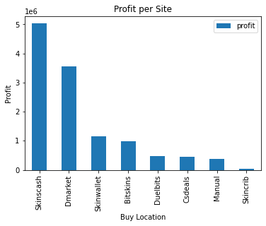

```python
aggr_trading = trading.groupby('buy_location').sum().sort_values('profit', ascending=False)


aggr_trading["profit"].plot(legend=True, kind="bar", title="Profit per Site", xlabel="Buy Location", ylabel="Profit")
```

Based on this chart we are able to see that the top three performers for total profit was 1) Skinscash 2) Dmarket 3) Skinwallet

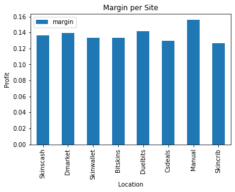

```python
aggr_trading["margin"] = (aggr_trading["sell_price"]/aggr_trading["buy_price"] - 1)

aggr_trading["margin"] = aggr_trading["margin"]

aggr_trading["margin"].plot(legend=True, kind="bar", title="Margin per Site", xlabel="Location", ylabel="Profit")
```

Based on this chart we are able to see that the top three performers for total profit per amount spent was

1. Manual
2. Duelbits
3. Dmarket

```python
print(aggr_trading["margin"].std())
print(aggr_trading["margin"].mean())
```

[output not shown]

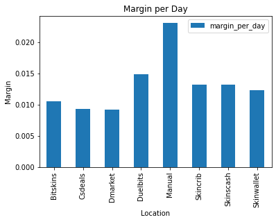

```python
aggr_trading_2 = trading.groupby('buy_location').mean()

aggr_trading_2["margin"] = aggr_trading["sell_price"]/aggr_trading["buy_price"]

aggr_trading_2["margin_per_day"] = (aggr_trading_2["margin"]-1)/aggr_trading_2["flip_time"]

aggr_trading_2["margin_per_day"].sort_values(ascending=False)

aggr_trading_2["margin_per_day"].plot(legend=True, kind="bar", title="Margin per Day", xlabel="Location", ylabel="Margin")
```

Based on this chart we are able to see that the top three performers for margin per day was

1. Manual
2. Duelbits
3. Skincrib

Going back to the first graph again, these locations are on the lower end of total volume. However, Manual is significantly above the other graphs so it would appear that there is actually some different there.

### Hypothesis Testing

Null hypothesis: A longer sell time will have no impact on margin

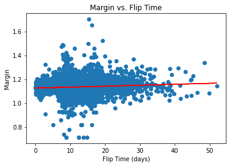

```
Line is: [0.00079143]x + [1.12557981]
```

```python
X = trading['Flip Time'].values.reshape(-1, 1)  # values converts it into a numpy array
Y = (trading['Sell Price']/trading['Buy Price']).values.reshape(-1, 1)  # -1 means that calculate the dimension of rows, but have 1 column
reg = LinearRegression()  # create object for the class
reg.fit(X, Y)  # perform linear regression
Y_pred = reg.predict(X)  # make predictions

plt.scatter(X, Y)
plt.plot(X, Y_pred, color='red')
plt.ylabel("Margin")
plt.xlabel("Flip Time (days)")
plt.title("Margin vs. Flip Time")
plt.show()

print('Line is: ' + str(reg.coef_[0]) + 'x + ' + str(reg.intercept_))
```

```python
pearsonr = sp.stats.pearsonr(X[:, 0], Y)
print(pearsonr[1])
```

```
8.453823234258804e-09
```

We have an extremely small p value so therefore we reject the null hypothesis and there is a very small but present impact that the margin increases as it takes longer to sell the items. The reason I believe this trend is in place is due to the fact the CSGO skin market has be generally increasing in average price since the database was started. However, the increase over a 1 month period is only .0237 (or 2.37%) change in margin.